# PyfA Assignment 3

**Learning topics:**

- Pandas multiindex
- Pandas data wrangling
- Creating and interpretting plots

**Datasets:**

- cdc_birth_data.csv
- marathon_dataset.csv

**Please do not share this material on any platform or by any other means.**

### **Important Notes:**

- Purpose of the assignment is to assess your knowledge and command of the Python programming language and your ability to resolve common errors. Grading is based on the code you are submitting, not the formatting of the results.
- Please use the examples as a guideline, you are not expected to have the same formatting as the example, unless it is a formatting question.
- Remember, there are many ways to code that can lead to the correct answer, do not hesitate to exercise your own style and python programming coventions.

# Pandas `MultiIndex`

## Q1A: Use the following data to create a Pandas Series object with `State` and `Year` as the index.

```
index = [('California',2000),('California',2010),
        ('New York', 2000),('New York',2010),
        ('Texas',2000),('Texas',2010)]
populations =[33871648,37253956,
             18976457,19378102,
             20851820,25145561]
```

```python
import pandas as pd
import numpy as np
```

```python
index = [('California',2000),('California',2010),
        ('New York', 2000),('New York',2010),
        ('Texas',2000),('Texas',2010)]
populations =[33871648,37253956,
             18976457,19378102,
             20851820,25145561]
```

```python
# add your code and explanation here
m_index = pd.MultiIndex.from_tuples(index)
m_index
m_index.set_names(['state', 'year'], inplace=True)
s1 = pd.Series(data=populations, index=m_index)
s1
```

```
state       year
California  2000    33871648
            2010    37253956
New York    2000    18976457
            2010    19378102
Texas       2000    20851820
            2010    25145561
dtype: int64
```

## Q1B:Choose all values from 2010.

```python
# add your code and explanation here
s1[:,2010]
```

```
state
California    37253956
New York      19378102
Texas         25145561
dtype: int64
```

## Q1C: Convert the series object created in 1A to a dataframe where index becomes `state` (name of the index is `state` as well).

```python
# add your code and explanation here
df = s1.to_frame()
df = df.reset_index()
df = df.set_index('state')
df
```

| state | year | 0 |
| --- | --- | --- |
| California | 2000 | 33871648 |
| California | 2010 | 37253956 |
| New York | 2000 | 18976457 |
| New York | 2010 | 19378102 |
| Texas | 2000 | 20851820 |
| Texas | 2010 | 25145561 |

# Pandas Data Wrangling

USA Centers for Disease Control and Prevention - US Birth Dataset (source: http://www.cdc.gov/nchs/data_access/Vitalstatsonline.htm)

Data dictionary: year, month, day, gender (F=Female or M= Male), births (number of births on the date)

## Question 2A: Read in the "cdc_birth_data.csv". Add a `decade` column (if year is 1969, the decade is 1960). Use a pivot table to show the total number of female and male births by decade. Interpret how male births compare to female births.

```python
# add your code and explanation here
data = pd.read_csv('cdc_birth_data.csv')
data.dropna(inplace=True)
data['decade'] = data['year'] - (data['year']%10)
table = pd.pivot_table(data, values='births',columns = 'gender',index=['decade'],
 aggfunc=np.sum, fill_value=0)
table
```

| gender decade | F | M |
| --- | --- | --- |
| 1960 | 1753634 | 1846572 |
| 1970 | 16263075 | 17121550 |
| 1980 | 16336639 | 17171471 |

Male birth is all bigger than female birth in all decade

## Question 2B: use a `Pandas.DataFrame.plot()` to show the total number of births by gender (using 2A)

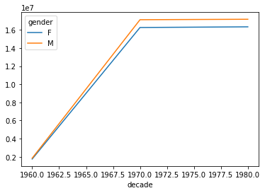

```python
table.plot()
```

## Question 2C: Calculate the 25th, 50th and 75th percentile of births data. (Hint: use np.percentile)

```python
# add your code and explanation here
q25 = np.percentile(data['births'],25)
q50 = np.percentile(data['births'],50)
q75 = np.percentile(data['births'],75)
q25
```

```
4344.0
```

## Question 2D: If sigma is defined as below, remove the records out side of 5sigma. Use the cleaned data in 2E and 2F.

`sigma = 0.74 * (quartile_75th - quartile_25th)`

`quartile_75th` and `quartile_25th` are calculated in 2c.

```python
# add your code and explanation here
sigma =  0.74 * (q75 - q25)
mean = data['births'].mean()
clean_data = data[(data['births'] <= mean+5*sigma) & (data['births'] >= mean-5*sigma)]
clean_data.head()
```

|  | year | month | day | gender | births | decade |
| --- | --- | --- | --- | --- | --- | --- |
| 0 | 1969 | 1 | 1.0 | F | 4046 | 1960 |
| 1 | 1969 | 1 | 1.0 | M | 4440 | 1960 |
| 2 | 1969 | 1 | 2.0 | F | 4454 | 1960 |
| 3 | 1969 | 1 | 2.0 | M | 4548 | 1960 |
| 4 | 1969 | 1 | 3.0 | F | 4548 | 1960 |

```python
clean_data
```

|  | year | month | day | gender | births | decade |
| --- | --- | --- | --- | --- | --- | --- |
| 0 | 1969 | 1 | 1.0 | F | 4046 | 1960 |
| 1 | 1969 | 1 | 1.0 | M | 4440 | 1960 |
| 2 | 1969 | 1 | 2.0 | F | 4454 | 1960 |
| 3 | 1969 | 1 | 2.0 | M | 4548 | 1960 |
| 4 | 1969 | 1 | 3.0 | F | 4548 | 1960 |
| ... | ... | ... | ... | ... | ... | ... |
| 15062 | 1988 | 12 | 29.0 | M | 5944 | 1980 |
| 15063 | 1988 | 12 | 30.0 | F | 5742 | 1980 |
| 15064 | 1988 | 12 | 30.0 | M | 6095 | 1980 |
| 15065 | 1988 | 12 | 31.0 | F | 4435 | 1980 |
| 15066 | 1988 | 12 | 31.0 | M | 4698 | 1980 |

14610 rows × 6 columns

## Question 2E: Create a graph that shows which day is the most popular dayof the week for giving birth in each decade.

To accomplish this goal, you can: Create a new column named `dayoftheweek`.(Monday==1) Plot mean of `birth` data by `dayoftheweek` for each `decade`.

**By looking at the graph, what can you tell about the popularity of Sundays vs Tuesdays?.**

```python
# add your code and explanation here
clean_data['day'] = clean_data.day.astype('int64')
clean_data['dayoftheweek'] = clean_data['day'] % 7
clean_data
```

|  | year | month | day | gender | births | decade | dayoftheweek |
| --- | --- | --- | --- | --- | --- | --- | --- |
| 0 | 1969 | 1 | 1 | F | 4046 | 1960 | 1 |
| 1 | 1969 | 1 | 1 | M | 4440 | 1960 | 1 |
| 2 | 1969 | 1 | 2 | F | 4454 | 1960 | 2 |
| 3 | 1969 | 1 | 2 | M | 4548 | 1960 | 2 |
| 4 | 1969 | 1 | 3 | F | 4548 | 1960 | 3 |
| ... | ... | ... | ... | ... | ... | ... | ... |
| 15062 | 1988 | 12 | 29 | M | 5944 | 1980 | 1 |
| 15063 | 1988 | 12 | 30 | F | 5742 | 1980 | 2 |
| 15064 | 1988 | 12 | 30 | M | 6095 | 1980 | 2 |
| 15065 | 1988 | 12 | 31 | F | 4435 | 1980 | 3 |
| 15066 | 1988 | 12 | 31 | M | 4698 | 1980 | 3 |

14610 rows × 7 columns

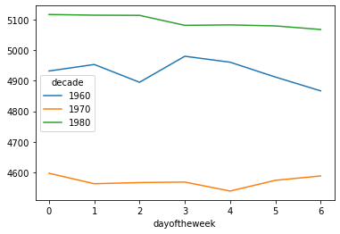

```python
dayofweek = clean_data.pivot_table('births', index='dayoftheweek', columns='decade', aggfunc='mean')
dayofweek.plot()
```

## Question 2F: Plot the average births by the day of the year.

You'll be plotting the average of births on each day Jan 1 through Dec 31st inclusive.

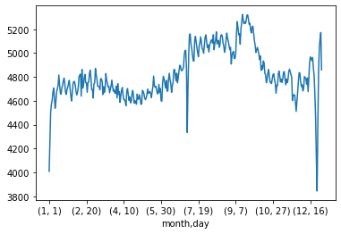

```python
# add your code and explanation here
clean_data.groupby(['month','day'])['births'].mean().plot()
```

# Plotting Data with `Seaborn` Library

## Question 3A: Read the marathon_dataset.csv and use `seaborn.joinplot()` to plot the relationship between the first-half marathon finishing time and the full-marathon finishing time.

**Data dictionary**: each observation shows the `age`, `gender` of the runner. `split_sec` is the finishing time of the first-half marathon. `final_sec` is the full-marathon finishing time.

```python
# add your code and explanation here
import seaborn as sns
mara = pd.read_csv('marathon_dataset.csv',delimiter = ';')
mara
```

|  | age | gender | split_sec | final_sec |
| --- | --- | --- | --- | --- |
| 0 | 33 | M | 3938.0 | 7731.0 |
| 1 | 32 | M | 3986.0 | 7768.0 |
| 2 | 31 | M | 4009.0 | 7842.0 |
| 3 | 38 | M | 3976.0 | 8025.0 |
| 4 | 31 | M | 3992.0 | 8039.0 |
| ... | ... | ... | ... | ... |
| 37245 | 18 | M | 15864.0 | 34377.0 |
| 37246 | 36 | M | 16543.0 | 34408.0 |
| 37247 | 51 | M | 15755.0 | 34420.0 |
| 37248 | 55 | W | 17886.0 | 36040.0 |
| 37249 | 58 | W | 17989.0 | 36068.0 |

37250 rows × 4 columns

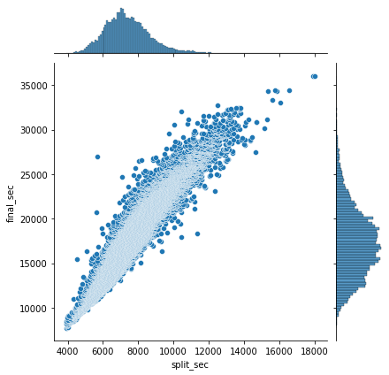

```python
sns.jointplot(x='split_sec', y='final_sec',
              data=mara, kind='scatter');
```

## Question 3B: Create a distribution plot of runners' racing strategy

Let's define a new variable, to identify the runners' racing strategy: *negative-split (those who have a slower first half and faster second half),* positive-split* (those who have a faster first half and slower second half).

```
racing_str = 1 - (2 * split_sec) / final_sec
```

If racing strategy is less than zero, this indicates runner's strategy is negative-split.

```python
mara.dtypes
```

```
age            int64
gender        object
split_sec    float64
final_sec    float64
dtype: object
```

```python
# add your code and explanation here
mara['racing_str'] = 1 - (2 * mara['split_sec']) / mara['final_sec']
mara['racing_str'] = np.where(mara['racing_str']<0 , 'negative_split', 'positive_split')
mara
```

|  | age | gender | split_sec | final_sec | racing_str |
| --- | --- | --- | --- | --- | --- |
| 0 | 33 | M | 3938.0 | 7731.0 | negative_split |
| 1 | 32 | M | 3986.0 | 7768.0 | negative_split |
| 2 | 31 | M | 4009.0 | 7842.0 | negative_split |
| 3 | 38 | M | 3976.0 | 8025.0 | positive_split |
| 4 | 31 | M | 3992.0 | 8039.0 | positive_split |
| ... | ... | ... | ... | ... | ... |
| 37245 | 18 | M | 15864.0 | 34377.0 | positive_split |
| 37246 | 36 | M | 16543.0 | 34408.0 | positive_split |
| 37247 | 51 | M | 15755.0 | 34420.0 | positive_split |
| 37248 | 55 | W | 17886.0 | 36040.0 | positive_split |
| 37249 | 58 | W | 17989.0 | 36068.0 | positive_split |

37250 rows × 5 columns

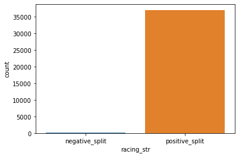

```python
sns.countplot(x='racing_str', data=mara);
```

## Question 3C: Are there any correlation between any of the variables? Explain.

You can use `sns.PairGrid` function or similar.

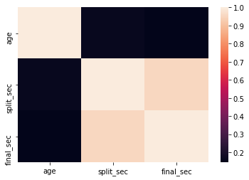

```python
# add your code and explanation here
corr_matrix = mara.corr()
sns.heatmap(corr_matrix)
```

```python
#split_sec and final_sec has trong correlation
```

## Question 3D: What is the distribution of race strategy by gender? What is your interpretation of the graph?

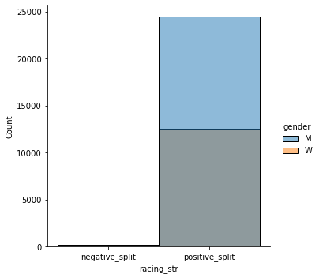

```python
# add your code and explanation here
sns.displot(x='racing_str', hue='gender', data=mara);
```

```python
#very few people use negative_split. There are more men than women
```

## Question 3E : Compare the distributions of men and women (3D) as a function of age, use a violin plot.

Create a column named `age_group` to group decade of age, e.g. if a person is 36 years old, `age_group` = 30. Then create a violin plot to show by age group by gender, the distribution of race strategy.

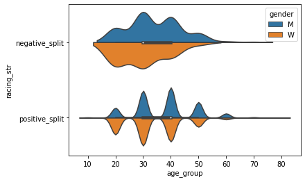

```python
# add your code and explanation here
mara['age_group'] = mara['age'] - (mara['age']%10)
sns.violinplot(data=mara,x='age_group',y='racing_str', hue='gender', split=True)
```